# Lab02 - Report

Jonathan Stuart

3/21/2018

## Introduction (describe the problem at hand, the data, background knowledge )

Human cytomagalovirus (HCMV) is a disease that effects somewhere between 30% and 80% of the population, varying geographically. Though the virus lays dormant once it infects a host, it can become harmful when it enters a productive cycle, replicating many thousands of copies of itself [1]. In this productive phase, it is most harmful to individuals with chronically weakened immune systems, and, additionally, is the leading cause of mental retardation and deafness at birth [2]. Being part of the Herpes family, biologists have hypothesized that patterns in the distribution of the virus’ DNA base pairs might give insight into the location of the site of replication. In an effort to mitigate the effects of this particular disease, we are faced with the problem of studying the distribution of base pair palindromes in order to locate the virus’ replication site. If we are able to develop methods to efficiently identify the locations of palindromes, we will have given researchers a reliable approach toward controlling the disease by impeding its spread and treating those already infected.

Along a strand of HCMV DNA, we have observed the existence of 229, 354 DNA base pairs. It has been further observed that, within these base pairs, 296 palindromes can be found, each between 10 and 18 base pairs long. Given that two other viruses in the Herpes family have replication sites marked by abnormal characteristics of base pair palindromes, research is underway to determine if HCMV does as well. To assist you in your research, we will determine if clusters of palindromes are non-random, and thereby indicative of DNA replication sites. In the process of this investigation, we will answer the following questions:

1. How do we find clusters of palindromes?
2. How do we determine whether a cluster is a chance occurrence or an indication of a replication site?

## Methodology (the statistical machinery you will be using for the report)

We used intervals of length 500, 2500, 4000, and 7000 base pairs which divided the data set into 458, 91, 57, and 32 intervals, respectively. This process was important due to the fact that the interval size had an impact on the goodness of fit of the Poisson distribution to the data; it was important to choose an interval size that was neither to large, nor too small. Once the data was partitioned into intervals of these sizes, we counted the number of palindromes in each interval. From these counts, we were then able to conduct a series of hypothesis tests to determine how well the Poisson distribution could describe the data we had been given.

## Results (the interpreted output of the methodology applied to the data)

Then, assuming applicability of the Poisson distribution, we can take lambda_hat to be x_bar, as an unbiased estimate for lambda. We then created vectors of observed and expected values, which can be seen below for each of the intervals.

### Tables of Expected and Observed Counts

| Interval Size | Expected Count | Observed Count |
| --- | --- | --- |
| 500 | 241 | 255 |
|  | 155 | 145 |
|  | 50 | 34 |
|  | 13 | 24 |

| Interval Size | Expected Count | Observed Count |
| --- | --- | --- |
| 2500 | 4 | 6 |
|  | 12 | 13 |
|  | 18 | 14 |
|  | 20 | 19 |
|  | 16 | 19 |
|  | 11 | 11 |
|  | 10 | 9 |

| Interval Size | Expected Count | Observed Count |
| --- | --- | --- |
| 4000 | 6 | 7 |
|  | 8 | 8 |
|  | 10 | 10 |
|  | 10 | 9 |
|  | 9 | 8 |
|  | 6 | 5 |
|  | 4 | 4 |
|  | 4 | 6 |

| Interval Size | Expected Count | Observed Count |
| --- | --- | --- |
| 7000 | 2 | 2 |
|  | 2 | 3 |
|  | 3 | 2 |
|  | 4 | 5 |
|  | 4 | 4 |
|  | 4 | 4 |
|  | 4 | 2 |
|  | 3 | 2 |
|  | 2 | 4 |
|  | 2 | 2 |
|  | 2 | 2 |

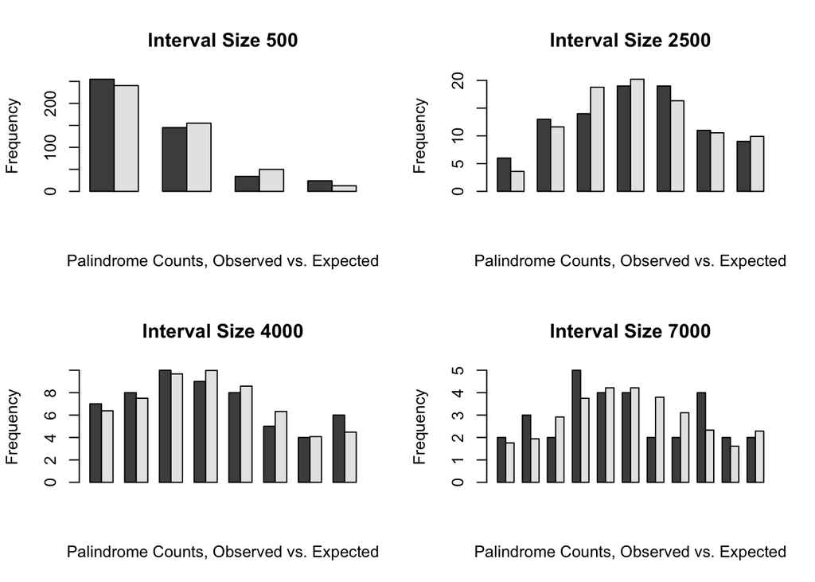

With these counts, we then conducted the chi-square goodness of fit test for the Poisson distribution with parameter $\hat\lambda$.

### Table of Chi-Square Values

| Interval Size | Chi-Square Value |
| --- | --- |
| 500 | 0.99988 |
| 2500 | 0.84980 |
| 4000 | 0.96025 |
| 7000 | 0.93652 |

Then, looking at the standardized residuals to see more closely where the fit occurs for each of the observed count totals, we found that the interval size of 4000 showed the best results, as residual values less than three in absolute value indicate goodness of fit. Here, we have a table to average residual values.

### Table of Average Residual Values

| Interval Size | Average Residual |
| --- | --- |
| 500 | 1.79 |
| 2500 | 0.6 |
| 4000 | 0.3 |
| 7000 | 0.5 |

We then generated the following 95% confidence intervals for the parameters lambda for each sized interval of base pairs. From these data, the tightest confidence interval appears to come from the 500 base pair interval.

### Table of Confidence Intervals

| Interval Size | Confidence Interval |
| --- | --- |
| 500 | 1.112293 |
| 2500 | 2.491117 |
| 4000 | 3.147584 |
| 7000 | 4.157788 |

Next we examined the distance between hits, as the inter-arrival time should approximate the exponential distribution if the Poisson distribution governs the data.

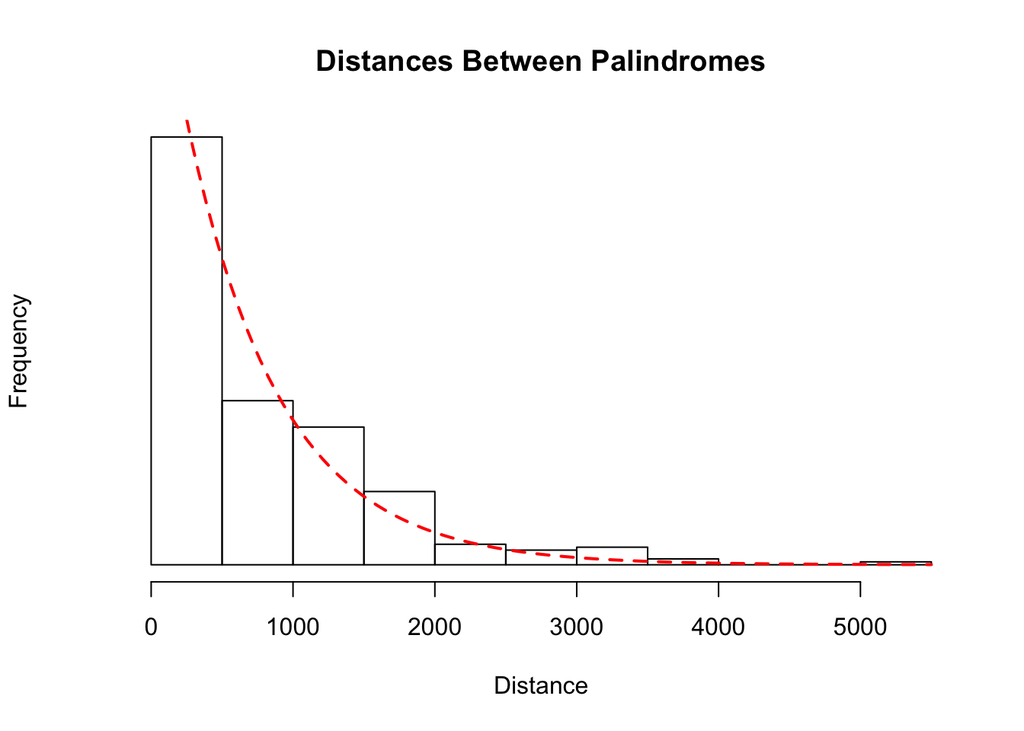

We also examined pairs, triplets, etc. of distances to inquire after the fitness of the gamma distribution. Here we have plots for pairs of distances.

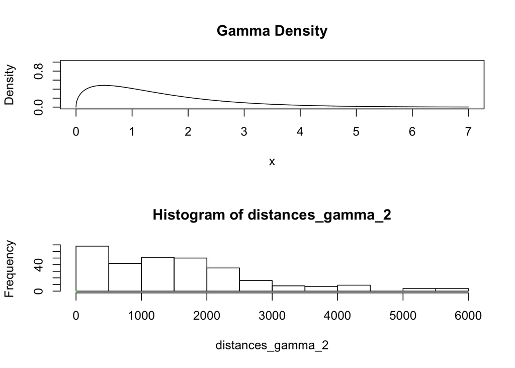

## Discussion (talk about the results, the limitations, etc)

Taking the results of all of these hypothesis tests into account, we decided upon an interval of 4000 base pairs, and made the conclusion that the Poisson distribution did in fact fit the given data. One limitation, however was the fact that the exponential distribution fit the inter-arrival time of palindromes, while the gamma distribution did not fit pairs of inter-arrival distances.

## Conclusion (recap the issue at hand, summarize your findings, etc)